# Static Variables

## Normal Operation (First)

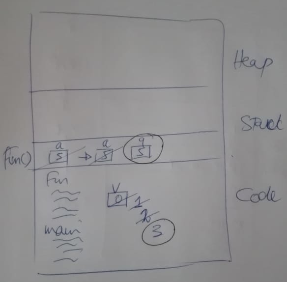

## How does it work

Global varianles are created at loading time before program execution, inside the code section.

So **v** is created in code section. **Main** is called (main activation record is created) no variables is created, it was only v but that was created at loading time. **Fun(( function is called (and fun activation record is created),** a **is created and set to** 5**. Inside Fun,** v** is incremented by 1.

So totals now is:

a=5 v=1

Fun exits, and memory is cleared, i.e **a** is deallocated, and Fun activation record is deleted.

Next Fun is called again, and a is created again, new version, and set to 5, and **v** gets incremented by 1.

So totals now is:

a=5 v=2

Next run, totals:

a=5 v=3

From the above we can see that local varianle **a** is initialised and removed every time, whereas the global variable **v** is kept **alive**, and maintains its value.

Now question is, is it possible to have the same behaviour for **a** as for **v**, but local to the **Fun** Function.

That is I want to keep a running total for **a**, keep alive, but I do not want to make **a** global

That is **a** should be global to **Fun** but not global to whole (main) program

Is this possible?

Lets explore below....

## Normal Operations

```python
#include <iostream>
#include <climits>
#include <math.h>
using namespace std;
```

```python
int v = 0;
int w = 0;
```

```python
void fun(){
    int a = 5;
    v++;
    cout<<a<< " "<<v<<endl;
}
```

```python
fun();
fun();
fun();
```

```
5 1
5 2
5 3
```

## (Global) Static Variable

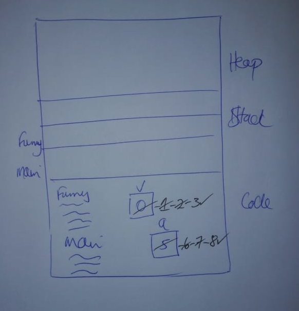

## How does it work

Same as above occurs as per normal operations when program starts, but now **a** is created in code section.

It (**a**) is now global to the program, but its scope is local to **fun** function (if that make sense).

```
static int aa = 5;
```

Meaning, its value is kept alive during the run of program, but it can only be accessed from **fun** function.

Thats is, although it is declared inside **Fun**, its value is not "reset" when you enter/exit **fun**

```python
void funny(){
    static int aa = 5;
    w++;
    aa++;
    cout<<aa<< " "<<w<<endl;
}
```

```python
funny();
funny();
funny();
```

```
6 1
7 2
8 3
```